# Brazil Cropland (Projected vs Observed)

Nick McManus

2022-07-28

```r
knitr::opts_chunk$set(echo = TRUE)
library(sf)  #polygons
library(raster) #raster package
library(terra)  #newer/faster/better raster package
library(rnaturalearth)  #administrative boundaries data
library(exactextractr)  #zonal stats
library(kableExtra) #tables
library(tidyverse) #always
library(caret) # for confusion matrix
```

## Read in Data & Reclassify

In this section, we will be reading in the GeoTiff rasters, then resampling, croping, and reclassifying the layers as needed for later analyses.

### ROI

Our region of interest is Brazil, so the shapefile for this country will be read in and used to crop LULC rasters.

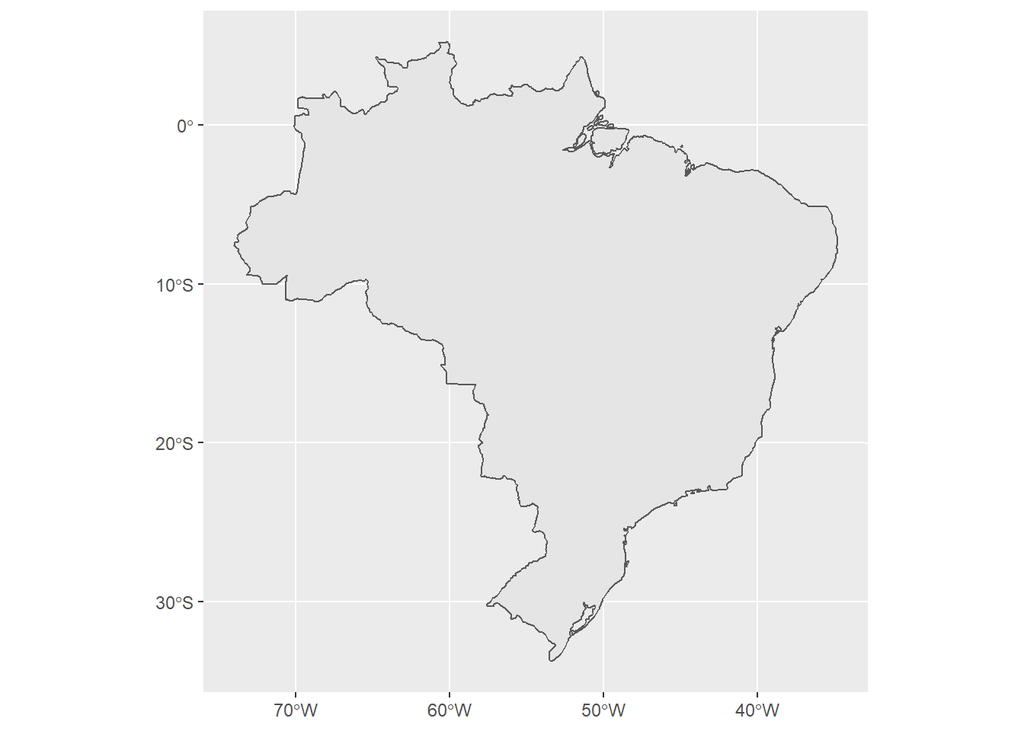

```r
# get brazil from rnaturalearth data
brazil <- ne_countries(
  scale = "medium",
  country = "Brazil",
  returnclass = "sf") %>%
  dplyr::select(sovereignt)

# plot to check
ggplot() +
  geom_sf(data = brazil)
```

### Projected Cropland

First read in projected 2020 cropland from Chen et al. 2022. Then, crop and mask this global projection to just Brazil. Finally, reclassify the raster to keep only pixels representing cropland.

Source: Chen, G., Li, X., & Liu, X. (2022). Global land projection based on plant functional types with a 1-km resolution under socio-climatic scenarios. Scientific Data, 9(1), 125. https://doi.org/10.1038/s41597-022-01208-6

```r
# read in GeoTiff for different SSP scenarios (other scenarios will be examined later)
chen_ssp1_2020_global <- rast("data/chen/global_PFT_SSP1_RCP26_2020.tif")   #SSP1
chen_ssp3_2020_global <- rast("data/chen/global_PFT_SSP3_RCP70_2020.tif")   #SSP3
chen_ssp5_2020_global <- rast("data/chen/global_PFT_SSP5_RCP85_2020.tif")   #SSP5

# transform brazil to crop chen raster bc it's faster than re-projecting the whole global raster
brazil_trans <- brazil %>%
  st_transform(crs = crs(chen_ssp1_2020_global)) %>%
  vect() # vect is more agreeable to rasts


# crop and mask chen data to brazil_trans vector, then project back to our desired crs
chen_ssp1_2020_brazil <- chen_ssp1_2020_global %>%
  crop(brazil_trans) %>%
  mask(brazil_trans) %>%
  terra::project(y = crs(brazil))
chen_ssp3_2020_brazil <- chen_ssp3_2020_global %>%
  crop(brazil_trans) %>%
  mask(brazil_trans) %>%
  terra::project(y = crs(brazil))
chen_ssp5_2020_brazil <- chen_ssp5_2020_global %>%
  crop(brazil_trans) %>%
  mask(brazil_trans) %>%
  terra::project(y = crs(brazil))
```

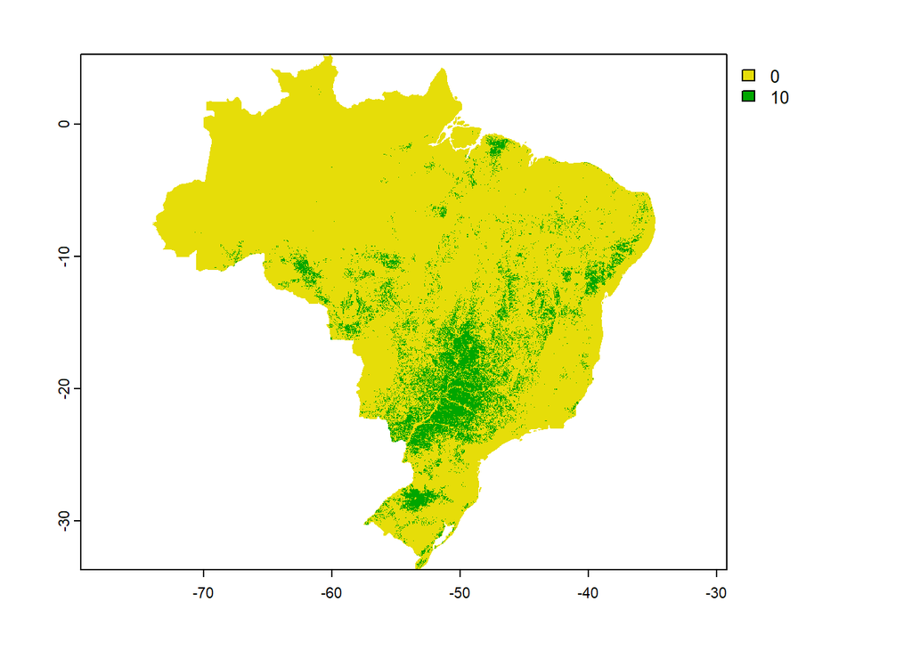

```r
# reclassify to isolate just cropland from the raster
# values assigned 0 and 10 for later visualization and calculations
chen_crop_ssp1_2020_brazil <- chen_ssp1_2020_brazil
  chen_crop_ssp1_2020_brazil[chen_crop_ssp1_2020_brazil != 18] <- 0 # if value isn't 18, make 0
  chen_crop_ssp1_2020_brazil[chen_crop_ssp1_2020_brazil == 18] <- 10 # if value is 18, make 10

chen_crop_ssp3_2020_brazil <- chen_ssp3_2020_brazil
  chen_crop_ssp3_2020_brazil[chen_crop_ssp3_2020_brazil != 18] <- 0 # if value isn't 18, make 0
  chen_crop_ssp3_2020_brazil[chen_crop_ssp3_2020_brazil == 18] <- 10 # if value is 18, make 10

chen_crop_ssp5_2020_brazil <- chen_ssp5_2020_brazil
  chen_crop_ssp5_2020_brazil[chen_crop_ssp5_2020_brazil != 18] <- 0 # if value isn't 18, make 0
  chen_crop_ssp5_2020_brazil[chen_crop_ssp5_2020_brazil == 18] <- 10 # if value is 18, make 10

plot(chen_crop_ssp1_2020_brazil)
```

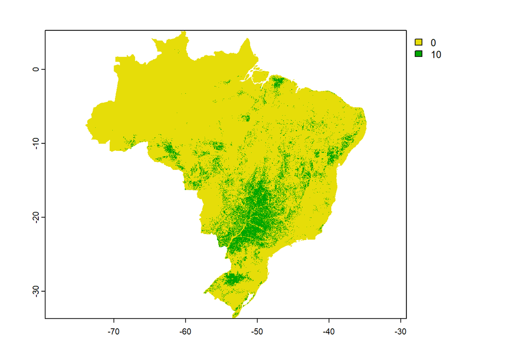

```r
plot(chen_crop_ssp3_2020_brazil)
```

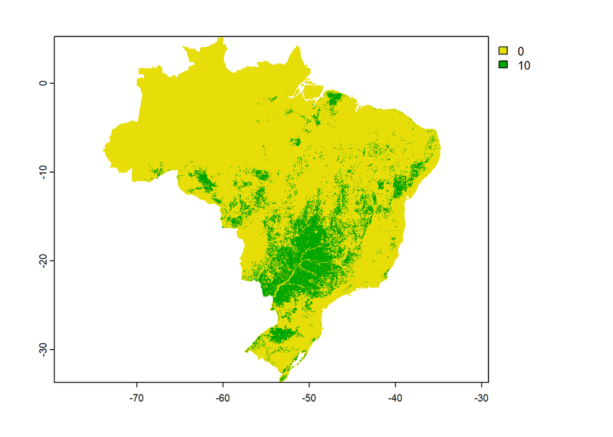

```r
plot(chen_crop_ssp5_2020_brazil)
```

### Observed Cropland

For observed cropland in Brazil, we will use data from MapBiomas (Collection 6), which uses Landsat mosaics to classify LULC at 30m resolution. After reading in the data, we want to resample the layer to match the resolution of Chen et al. LULC.

(More information and GeoTiff source found at: https://mapbiomas.org/en/colecoes-mapbiomas-1?cama_set_language=en)

```r
# WARNING: below analysis (aggregate step) will take a long time to run!
# Once run, the last line of code in this chunk will save the intermediate raster locally.
# If this has been already run once, skip running this chunk and move on to next


# read in GeoTiff
mapbio_2020 <- rast("data/mapbiomas/brasil_coverage_2020.tif")

# change resolution from 30m to roughly 1km
# to figure out factor that gets res closest to target raster (Chen), use this:
factor <- ceiling(res(chen_crop_ssp1_2020_brazil)[1]/res(mapbio_2020)[1])
factor

# now change resolution using terra:aggregate()
mapbio_2020_agg <- aggregate(mapbio_2020,   #raster
                            fact = 34,            #agg factor (positive int)
                            fun = "modal",        #categorical values in raster
                            na.rm = TRUE)         #don't drop entire aggregation bc of one NA

# resample lower res mapbiomas using Chen data to ensure same resolution (fine-tuning the res)
mapbio_2020_resamp <- resample(mapbio_2020_agg, chen_crop_ssp1_2020_brazil, method = "near")

# because crs of mapbiomas and chen rasters are different, repeat process of
# transforming brazil for purposes of cropping and masking
brazil_trans2 <- brazil %>%
  st_transform(crs = crs(mapbio_2020_resamp)) %>%
  vect()

# crop and mask mapbiomas layer to ROI
mapbio_2020_cropped <- mapbio_2020_resamp %>%
  crop(brazil_trans2, mask = TRUE)

# save intermediate raster
#writeRaster(mapbio_2020_cropped, "data/mapbiomas/mapbiomas_2020_cropped.tif")
```

Now that Mapbiomas data has been aggregated, resampled, and cropped, it’s time to reclassify the raster to select for LULC categories of interest. Cropland data for analysis will be defined as “agriculture” from the MapBiomas classification, which includes temporary and perennial crops but omits pasture and mosaic agriculture. Later on, we want to see how including the mosaic agriculture and pasture land classification affects the (agreement) between Chen and Mapbiomas datasets. This requires creating `mapbio_crop_2020_mosaic`, a separate classification that includes mosaic agriculture.

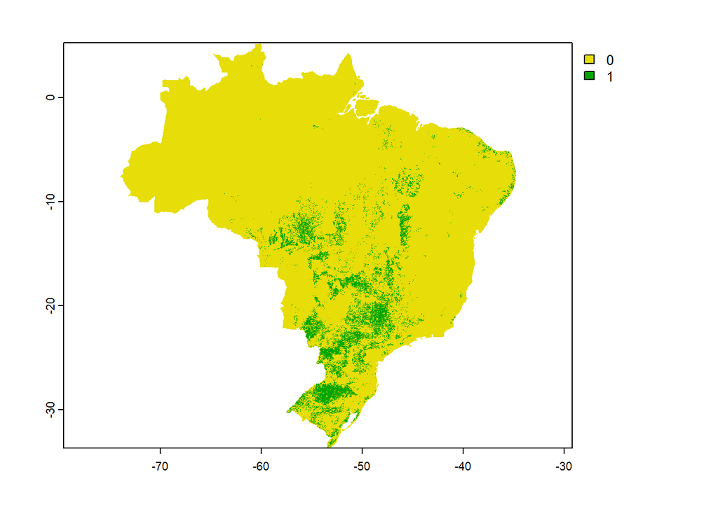

```r
# if above code chunk has been previously run, read in raster for analysis:
mapbio_2020_cropped <- rast("data/mapbiomas/mapbiomas_2020_cropped.tif")

## create reclassification matrix to combine and keep only cropland categories
reclass_df <- c(3, 0,   #forest formation
                4, 0,   #savanna formation
                5, 0,   #mangrove
                49, 0,  #wooded restinga
                11, 0,  #wetlands
                12, 0,  #grassland
                32, 0,  #salt flat
                29, 0,  #rocky outcrop
                13, 0,  #other nonforest formations
                15, 0,  #pasture
                9, 0,   #forest plantation
                21, 0,  #mosaic ag and pasture
                23, 0,  #beach, dune, and sand spot
                24, 0,  #urban area
                30, 0,  #mining
                25, 0,  #other non vegetated areas
                33, 0,  # river, lake, ocean
                31, 0,  #aquaculture
                27, 0,  #non observed
                39, 1,  #soybean
                20, 1,  #sugar cane
                40, 1,  #rice
                41, 1,  #other temp crops
                46, 1,  #coffee
                47, 1,  #citrus
                48, 1)  #other perennial crops

# reshape df into matrix with columns and rows
reclass_m <- matrix(reclass_df, ncol = 2, byrow = TRUE)

# use terra:classify() to reclassify raster values based on matrix
mapbio_2020_reclass <- classify(mapbio_2020_cropped, reclass_m)

# crs do not match, so use terra::project() to match with chen raster
mapbio_crop_2020 <- project(mapbio_2020_reclass, crs(chen_crop_ssp1_2020_brazil), method = "near")

# plot results
plot(mapbio_crop_2020)
```

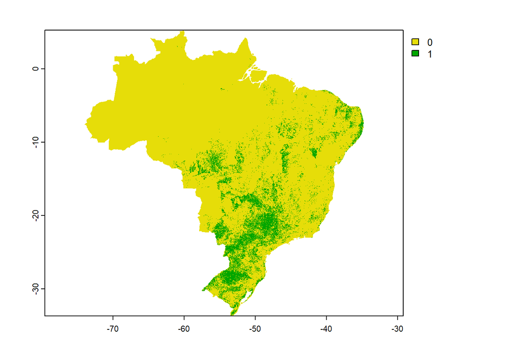

```r
## include ag mosaic in new reclassification
reclass_df_mosaic <- c(3, 0,   #forest formation
                4, 0,   #savanna formation
                5, 0,   #mangrove
                49, 0,  #wooded restinga
                11, 0,  #wetlands
                12, 0,  #grassland
                32, 0,  #salt flat
                29, 0,  #rocky outcrop
                13, 0,  #other nonforest formations
                15, 0,  #pasture
                9, 0,   #forest plantation
                21, 1,  #mosaic ag and pasture
                23, 0,  #beach, dune, and sand spot
                24, 0,  #urban area
                30, 0,  #mining
                25, 0,  #other non vegetated areas
                33, 0,  # river, lake, ocean
                31, 0,  #aquaculture
                27, 0,  #non observed
                39, 1,  #soybean
                20, 1,  #sugar cane
                40, 1,  #rice
                41, 1,  #other temp crops
                46, 1,  #coffee
                47, 1,  #citrus
                48, 1)  #other perennial crops

reclass_m_mosaic <- matrix(reclass_df_mosaic, ncol = 2, byrow = TRUE)

mapbio_2020_reclass_mosaic <- classify(mapbio_2020_cropped, reclass_m_mosaic)

mapbio_crop_2020_mosaic <- project(mapbio_2020_reclass_mosaic, crs(chen_crop_ssp1_2020_brazil), method = "near")

#plot results
plot(mapbio_crop_2020_mosaic)
```

## Confusion matrix

Now we will compare projects vs observed cropland within Brazil. This will be done using a confusion matrix.

### Only cropland

Create confusion matrix to view sensitivity (true positive) and specificity of Chen 2020 and MapBiomas 2020 (cropland only) data.

#### SSP1

View the results when comparing Chen SSP1 2020 vs. MapBiomas 2020

```r
# add chen and mapbiomas rasters
chen_mapbio_ssp1_2020 <- mapbio_crop_2020 + chen_crop_ssp1_2020_brazil

# return frequency of each value (0, 1, 10, 11) in new raster
counts1 <- freq(chen_mapbio_ssp1_2020)

# break up freq values by classification meaning
nocrop_1 <- counts1[1, 3]
crop_mapbio_only_1 <- counts1[2, 3]
crop_chen_only_1 <- counts1[3,3]
crop_both_1 <- counts1[4,3]


## break down into values for confusion matrix

# number of real positive cases (P), pixels for which mapbiomas observed cropland
p_1 <- crop_mapbio_only_1 + crop_both_1
# number of real negative cases (N), pixels for which mapbiomas did not observe cropland
n_1 <- nocrop_1 + crop_chen_only_1

# true positive
tp_1 <- crop_both_1
# false positive
fp_1 <- crop_chen_only_1
# true negative
tn_1 <- nocrop_1
# false negative
fn_1 <- crop_mapbio_only_1

## percentages/rates:
# sensitivity (true positive rate)
tpr_1 <- tp_1/p_1
# specificity (true negative rate)
tnr_1 <- tn_1/n_1
# false positive rate
fpr_1 <- fp_1/n_1
# false negative rate
fnr_1 <- fn_1/p_1

#accuracy
acc_1 <- (tp_1 + tn_1)/(p_1 + n_1)
#precision (positive predictive value)
ppv_1 <- tp_1/(tp_1 + fp_1)

cm_ssp1_2020 <- matrix(c(tp_1, fn_1, fp_1, tn_1), ncol=2, byrow=TRUE)
colnames(cm_ssp1_2020) <- c("Predicted Pos", "Predicted Neg")
rownames(cm_ssp1_2020) <- c("Observed Pos", "Observed Neg")

# cm of rates
cm_ssp1_2020_perc <- matrix(c(tpr_1, fnr_1, fpr_1, tnr_1), ncol=2, byrow=TRUE)
colnames(cm_ssp1_2020_perc) <- c("Predicted Pos", "Predicted Neg")
rownames(cm_ssp1_2020_perc) <- c("Observed Pos", "Observed Neg")

cm_ssp1_2020
```

```
##              Predicted Pos Predicted Neg
## Observed Pos        329670        306379
## Observed Neg        627858       7225051
```

```r
cm_ssp1_2020_perc
```

```
##              Predicted Pos Predicted Neg
## Observed Pos    0.51830912     0.4816909
## Observed Neg    0.07995228     0.9200477
```

```r
acc_1
```

```
##     count
## 0.8899468
```

```r
ppv_1
```

```
##     count
## 0.3442928
```

Visualize overlap between crop classifications of Chen SSP1 and MapBiomas rasters.

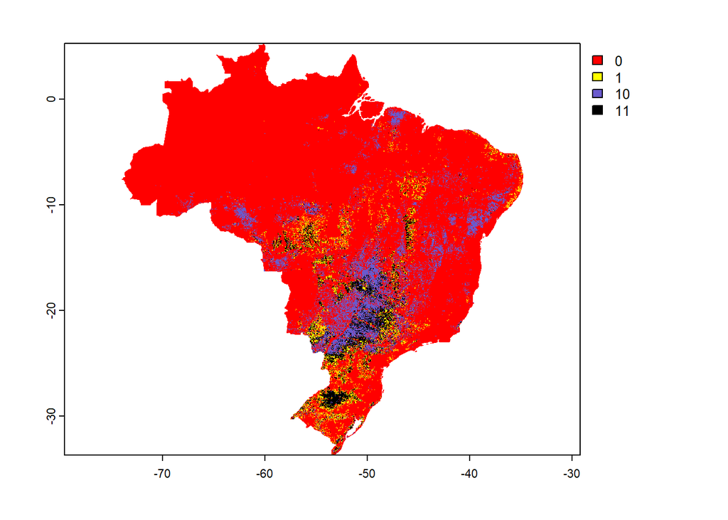

```r
# plot combined layer
plot(chen_mapbio_ssp1_2020, col = c("red", "yellow", "slateblue", "black"))
```

```r
# add legend! convert to vect and sf then put in ggplot?
```

#### SSP3

View the results when comparing Chen SSP3 2020 vs. MapBiomas 2020

```r
# add chen and mapbiomas rasters
chen_mapbio_ssp3_2020 <- mapbio_crop_2020 + chen_crop_ssp3_2020_brazil

# return frequency of each value (0, 1, 10, 11) in new raster
counts3 <- freq(chen_mapbio_ssp3_2020)

# break up freq values by classification meaning
nocrop_3 <- counts3[1, 3]
crop_mapbio_only_3 <- counts3[2, 3]
crop_chen_only_3 <- counts3[3,3]
crop_both_3 <- counts3[4,3]


## break down into values for confusion matrix

# number of real positive cases (P), pixels for which mapbiomas observed cropland
p_3 <- crop_mapbio_only_3 + crop_both_3
# number of real negative cases (N), pixels for which mapbiomas did not observe cropland
n_3 <- nocrop_3 + crop_chen_only_3

# true positive
tp_3 <- crop_both_3
# false positive
fp_3 <- crop_chen_only_3
# true negative
tn_3 <- nocrop_3
# false negative
fn_3 <- crop_mapbio_only_3

## percentages/rates:
# sensitivity (true positive rate)
tpr_3 <- tp_3 / p_3
# specificity (true negative rate)
tnr_3 <- tn_3/n_3
# false positive rate
fpr_3 <- fp_3/n_3
# false negative rate
fnr_3 <- fn_3/p_3

#accuracy
acc_3 <- (tp_3 + tn_3)/(p_3 + n_3)
#precision (positive predictive value)
ppv_3 <- tp_3/(tp_3 + fp_3)

cm_ssp3_2020 <- matrix(c(tp_3, fn_3, fp_3, tn_3), ncol=2, byrow=TRUE)
colnames(cm_ssp3_2020) <- c("Predicted Pos", "Predicted Neg")
rownames(cm_ssp3_2020) <- c("Observed Pos", "Observed Neg")

# cm of rates
cm_ssp3_2020_perc <- matrix(c(tpr_3, fnr_3, fpr_3, tnr_3), ncol=2, byrow=TRUE)
colnames(cm_ssp3_2020_perc) <- c("Predicted Pos", "Predicted Neg")
rownames(cm_ssp3_2020_perc) <- c("Observed Pos", "Observed Neg")

cm_ssp3_2020
```

```
##              Predicted Pos Predicted Neg
## Observed Pos        342071        293978
## Observed Neg        664827       7188082
```

```r
cm_ssp3_2020_perc
```

```
##              Predicted Pos Predicted Neg
## Observed Pos    0.53780605      0.462194
## Observed Neg    0.08465996      0.915340
```

```r
acc_3
```

```
##     count
## 0.8870527
```

```r
ppv_3
```

```
##     count
## 0.3397276
```

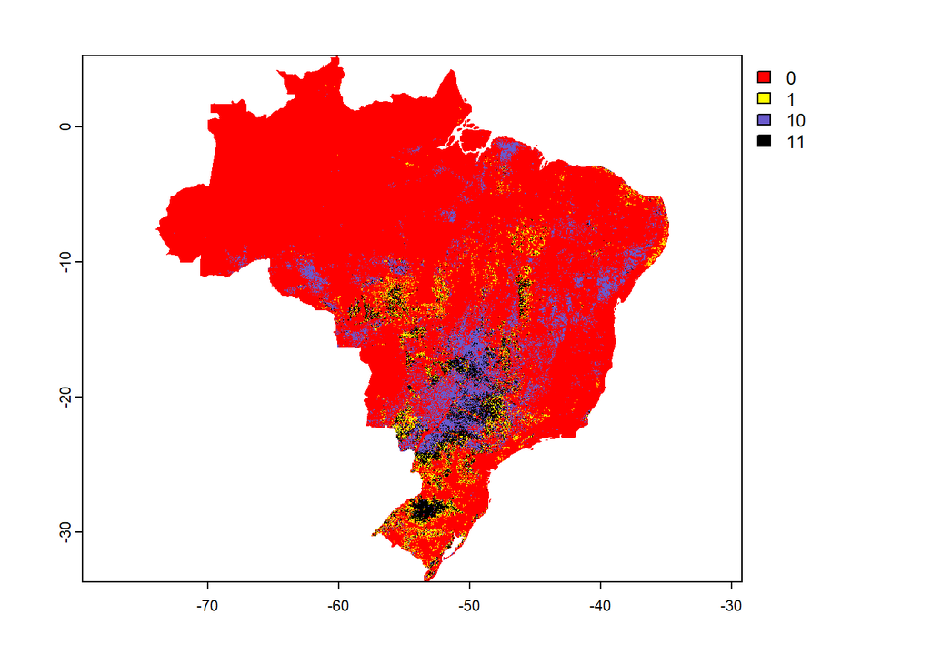

```r
# plot combined layer
plot(chen_mapbio_ssp3_2020, col = c("red", "yellow", "slateblue", "black"))
```

```r
# add legend! convert to vect and sf then put in ggplot?
```

#### SSP5

View the results when comparing Chen SSP5 2020 vs. MapBiomas 2020

```r
# add chen and mapbiomas rasters
chen_mapbio_ssp5_2020 <- mapbio_crop_2020 + chen_crop_ssp5_2020_brazil

# return frequency of each value (0, 1, 10, 11) in new raster
counts5 <- freq(chen_mapbio_ssp5_2020)

# break up freq values by classification meaning
nocrop_5 <- counts5[1, 3]
crop_mapbio_only_5 <- counts5[2, 3]
crop_chen_only_5 <- counts5[3,3]
crop_both_5 <- counts5[4,3]


## break down into values for confusion matrix

# number of real positive cases (P), pixels for which mapbiomas observed cropland
p_5 <- crop_mapbio_only_5 + crop_both_5
# number of real negative cases (N), pixels for which mapbiomas did not observe cropland
n_5 <- nocrop_5 + crop_chen_only_5

# true positive
tp_5 <- crop_both_5
# false positive
fp_5 <- crop_chen_only_5
# true negative
tn_5 <- nocrop_5
# false negative
fn_5 <- crop_mapbio_only_5

## percentages/rates:
# sensitivity (true positive rate)
tpr_5 <- tp_5 / p_5
# specificity (true negative rate)
tnr_5 <- tn_5/n_5
# false positive rate
fpr_5 <- fp_5/n_5
# false negative rate
fnr_5 <- fn_5/p_5

#accuracy
acc_5 <- (tp_5 + tn_5)/(p_5 + n_5)
#precision (positive predictive value)
ppv_5 <- tp_5/(tp_5 + fp_5)

cm_ssp5_2020 <- matrix(c(tp_5, fn_5, fp_5, tn_5), ncol=2, byrow=TRUE)
colnames(cm_ssp5_2020) <- c("Predicted Pos", "Predicted Neg")
rownames(cm_ssp5_2020) <- c("Observed Pos", "Observed Neg")

# cm of rates
cm_ssp5_2020_perc <- matrix(c(tpr_5, fnr_5, fpr_5, tnr_5), ncol=2, byrow=TRUE)
colnames(cm_ssp5_2020_perc) <- c("Predicted Pos", "Predicted Neg")
rownames(cm_ssp5_2020_perc) <- c("Observed Pos", "Observed Neg")

cm_ssp5_2020
```

```
##              Predicted Pos Predicted Neg
## Observed Pos        415557        220492
## Observed Neg        904644       6948265
```

```r
cm_ssp5_2020_perc
```

```
##              Predicted Pos Predicted Neg
## Observed Pos     0.6533412     0.3466588
## Observed Neg     0.1151986     0.8848014
```

```r
acc_5
```

```
##     count
## 0.8674589
```

```r
ppv_5
```

```
##    count
## 0.314768
```

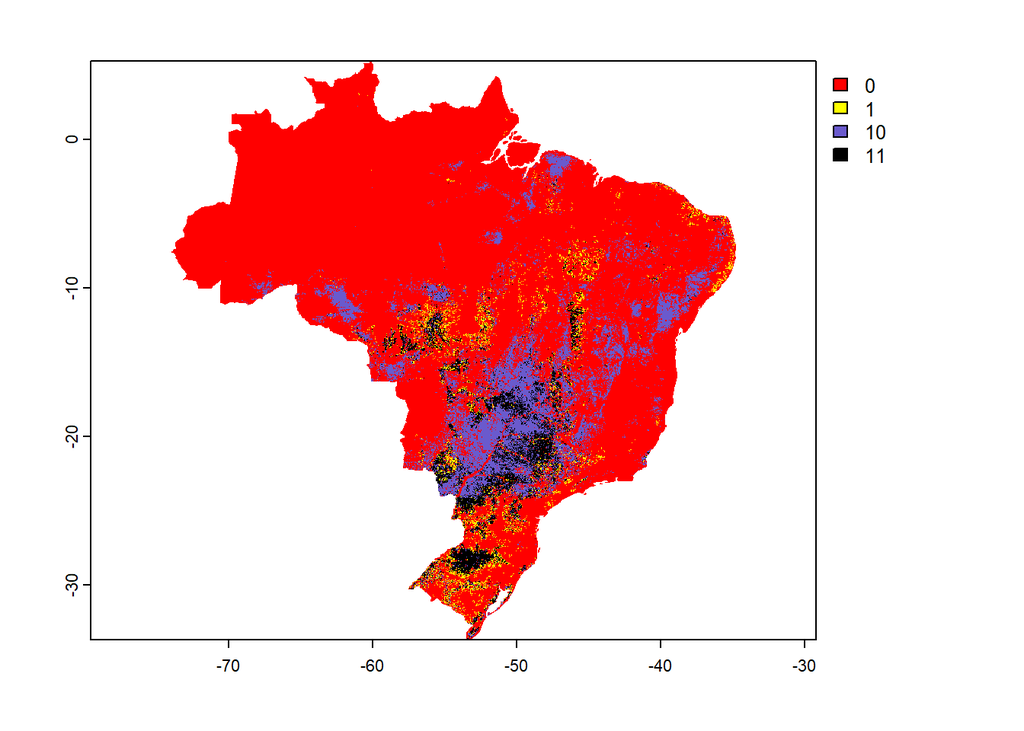

```r
# plot combined layer
plot(chen_mapbio_ssp5_2020, col = c("red", "yellow", "slateblue", "black"))
```

```r
# add legend! convert to vect and sf then put in ggplot?
```

### Cropland + Mosaic ag

Check how overlap and confusion matrix change if mosaic ag and pasture is included into MapBiomas 2020 data

#### SSP1

```r
# add chen and mapbiomas rasters
chen_mapbio_ssp1_2020_mosaic <- mapbio_crop_2020_mosaic + chen_crop_ssp1_2020_brazil

# return frequency of each value (0, 1, 10, 11) in new raster
counts_1m <- freq(chen_mapbio_ssp1_2020_mosaic)
counts_1m
```

```
##      layer value   count
## [1,]     1     0 7017273
## [2,]     1     1  514157
## [3,]     1    10  555279
## [4,]     1    11  402249
```

```r
# break up freq values ba
nocrop_1m <- counts_1m[1, 3]
crop_mapbio_only_1m <- counts_1m[2, 3]
crop_chen_only_1m <- counts_1m[3,3]
crop_both_1m <- counts_1m[4,3]


## break down into values for confusion matrix

# number of real positive cases (P), pixels for which mapbiomas observed cropland
p_1m <- crop_mapbio_only_1m + crop_both_1m
# number of real negative cases (N), pixels for which mapbiomas did not observe cropland
n_1m <- nocrop_1m + crop_chen_only_1m

# true positive
tp_1m <- crop_both_1m
# false positive
fp_1m <- crop_chen_only_1m
# true negative
tn_1m <- nocrop_1m
# false negative
fn_1m <- crop_mapbio_only_1m

## percentages/rates:
# sensitivity (true positive rate)
tpr_1m <- tp_1m/p_1m
# specificity (true negative rate)
tnr_1m <- tn_1m/n_1m
# false positive rate
fpr_1m <- fp_1m/n_1m
# false negative rate
fnr_1m <- fn_1m/p_1m

#accuracy
acc_1m <- (tp_1m + tn_1m)/(p_1m + n_1m)
#precision (positive predictive value)
ppv_1m <- tp_1m/(tp_1m + fp_1m)

cm_ssp1_2020_m <- matrix(c(tp_1m, fn_1m, fp_1m, tn_1m), ncol=2, byrow=TRUE)
colnames(cm_ssp1_2020_m) <- c("Predicted Pos", "Predicted Neg")
rownames(cm_ssp1_2020_m) <- c("Observed Pos", "Observed Neg")

# cm of rates
cm_ssp1_2020_perc_m <- matrix(c(tpr_1m, fnr_1m, fpr_1m, tnr_1m), ncol=2, byrow=TRUE)
colnames(cm_ssp1_2020_perc_m) <- c("Predicted Pos", "Predicted Neg")
rownames(cm_ssp1_2020_perc_m) <- c("Observed Pos", "Observed Neg")

cm_ssp1_2020_m
```

```
##              Predicted Pos Predicted Neg
## Observed Pos        402249        514157
## Observed Neg        555279       7017273
```

```r
cm_ssp1_2020_perc_m
```

```
##              Predicted Pos Predicted Neg
## Observed Pos    0.43894191     0.5610581
## Observed Neg    0.07332786     0.9266721
```

```r
acc_1m
```

```
##     count
## 0.8740203
```

```r
ppv_1m
```

```
##     count
## 0.4200911
```

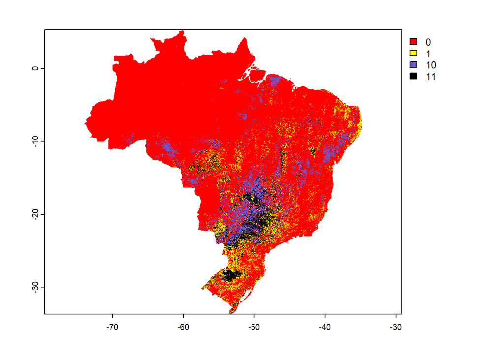

```r
# plot combined layer
plot(chen_mapbio_ssp1_2020_mosaic, col = c("red", "yellow", "slateblue", "black"))
```

#### SSP3

```r
# add chen and mapbiomas rasters
chen_mapbio_ssp3_2020_mosaic <- mapbio_crop_2020_mosaic + chen_crop_ssp3_2020_brazil

# return frequency of each value (0, 1, 10, 11) in new raster
counts_3m <- freq(chen_mapbio_ssp3_2020_mosaic)
counts_3m
```

```
##      layer value   count
## [1,]     1     0 6982874
## [2,]     1     1  499186
## [3,]     1    10  589678
## [4,]     1    11  417220
```

```r
# break up freq values ba
nocrop_3m <- counts_3m[1, 3]
crop_mapbio_only_3m <- counts_3m[2, 3]
crop_chen_only_3m <- counts_3m[3,3]
crop_both_3m <- counts_3m[4,3]


## break down into values for confusion matrix

# number of real positive cases (P), pixels for which mapbiomas observed cropland
p_3m <- crop_mapbio_only_3m + crop_both_3m
# number of real negative cases (N), pixels for which mapbiomas did not observe cropland
n_3m <- nocrop_3m + crop_chen_only_3m

# true positive
tp_3m <- crop_both_3m
# false positive
fp_3m <- crop_chen_only_3m
# true negative
tn_3m <- nocrop_3m
# false negative
fn_3m <- crop_mapbio_only_3m

## percentages/rates:
# sensitivity (true positive rate)
tpr_3m <- tp_3m/p_3m
# specificity (true negative rate)
tnr_3m <- tn_3m/n_3m
# false positive rate
fpr_3m <- fp_3m/n_3m
# false negative rate
fnr_3m <- fn_3m/p_3m

#accuracy
acc_3m <- (tp_3m + tn_3m)/(p_3m + n_3m)
#precision (positive predictive value)
ppv_3m <- tp_3m/(tp_3m + fp_3m)

cm_ssp3_2020_m <- matrix(c(tp_3m, fn_3m, fp_3m, tn_3m), ncol=2, byrow=TRUE)
colnames(cm_ssp3_2020_m) <- c("Predicted Pos", "Predicted Neg")
rownames(cm_ssp3_2020_m) <- c("Observed Pos", "Observed Neg")

# cm of rates
cm_ssp3_2020_perc_m <- matrix(c(tpr_3m, fnr_3m, fpr_3m, tnr_3m), ncol=2, byrow=TRUE)
colnames(cm_ssp3_2020_perc_m) <- c("Predicted Pos", "Predicted Neg")
rownames(cm_ssp3_2020_perc_m) <- c("Observed Pos", "Observed Neg")

cm_ssp3_2020_m
```

```
##              Predicted Pos Predicted Neg
## Observed Pos        417220        499186
## Observed Neg        589678       6982874
```

```r
cm_ssp3_2020_perc_m
```

```
##              Predicted Pos Predicted Neg
## Observed Pos    0.45527856     0.5447214
## Observed Neg    0.07787045     0.9221296
```

```r
acc_3m
```

```
##     count
## 0.8717317
```

```r
ppv_3m
```

```
##     count
## 0.4143617
```

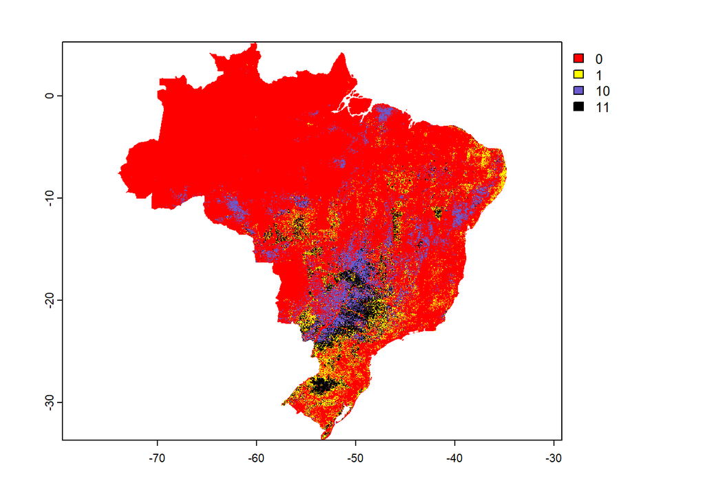

```r
# plot combined layer
plot(chen_mapbio_ssp3_2020_mosaic, col = c("red", "yellow", "slateblue", "black"))
```

#### SSP5

```r
# add chen and mapbiomas rasters
chen_mapbio_ssp5_2020_mosaic <- mapbio_crop_2020_mosaic + chen_crop_ssp5_2020_brazil

# return frequency of each value (0, 1, 10, 11) in new raster
counts_5m <- freq(chen_mapbio_ssp5_2020_mosaic)
counts_5m
```

```
##      layer value   count
## [1,]     1     0 6767686
## [2,]     1     1  401071
## [3,]     1    10  804866
## [4,]     1    11  515335
```

```r
# break up freq values ba
nocrop_5m <- counts_5m[1, 3]
crop_mapbio_only_5m <- counts_5m[2, 3]
crop_chen_only_5m <- counts_5m[3,3]
crop_both_5m <- counts_5m[4,3]


## break down into values for confusion matrix

# number of real positive cases (P), pixels for which mapbiomas observed cropland
p_5m <- crop_mapbio_only_5m + crop_both_5m
# number of real negative cases (N), pixels for which mapbiomas did not observe cropland
n_5m <- nocrop_5m + crop_chen_only_5m

# true positive
tp_5m <- crop_both_5m
# false positive
fp_5m <- crop_chen_only_5m
# true negative
tn_5m <- nocrop_5m
# false negative
fn_5m <- crop_mapbio_only_5m

## percentages/rates:
# sensitivity (true positive rate)
tpr_5m <- tp_5m/p_5m
# specificity (true negative rate)
tnr_5m <- tn_5m/n_5m
# false positive rate
fpr_5m <- fp_5m/n_5m
# false negative rate
fnr_5m <- fn_5m/p_5m

#accuracy
acc_5m <- (tp_5m + tn_5m)/(p_5m + n_5m)
#precision (positive predictive value)
ppv_5m <- tp_5m/(tp_5m + fp_5m)

cm_ssp5_2020_m <- matrix(c(tp_5m, fn_5m, fp_5m, tn_5m), ncol=2, byrow=TRUE)
colnames(cm_ssp5_2020_m) <- c("Predicted Pos", "Predicted Neg")
rownames(cm_ssp5_2020_m) <- c("Observed Pos", "Observed Neg")

# cm of rates
cm_ssp5_2020_perc_m <- matrix(c(tpr_5m, fnr_5m, fpr_5m, tnr_5m), ncol=2, byrow=TRUE)
colnames(cm_ssp5_2020_perc_m) <- c("Predicted Pos", "Predicted Neg")
rownames(cm_ssp5_2020_perc_m) <- c("Observed Pos", "Observed Neg")

cm_ssp5_2020_m
```

```
##              Predicted Pos Predicted Neg
## Observed Pos        515335        401071
## Observed Neg        804866       6767686
```

```r
cm_ssp5_2020_perc_m
```

```
##              Predicted Pos Predicted Neg
## Observed Pos     0.5623435     0.4376565
## Observed Neg     0.1062873     0.8937127
```

```r
acc_5m
```

```
##     count
## 0.8579405
```

```r
ppv_5m
```

```
##     count
## 0.3903459
```

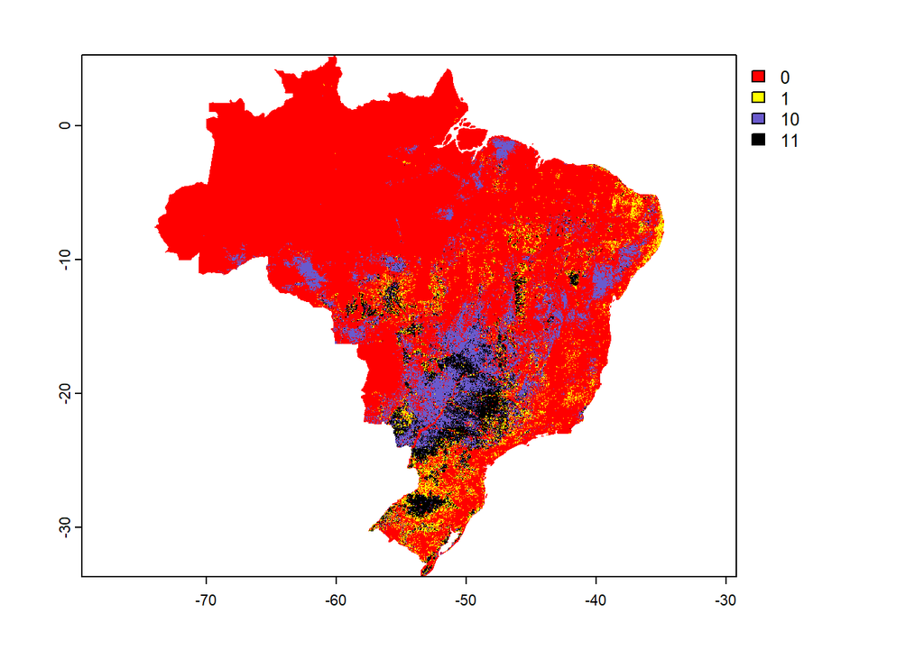

```r
# plot combined layer
plot(chen_mapbio_ssp5_2020_mosaic, col = c("red", "yellow", "slateblue", "black"))
```

## Checking “baseline” datasets

Checking the sensitivity and specificity of Chen 2015 and Mapbiomas 2015, both considered “observed” models. This requires reading in and repeating several previous steps for new raster layer. Then we will create the confusion matrices and visualize the results.

### Read in data

First read in, crop, mask, and reclassify 2015 Chen raster

```r
# read in GeoTiff for 2015 Chen
chen_2015_global <- rast("data/chen/global_PFT_2015.tif")

# crop and mask chen data to brazil_trans vector, then project back to our desired crs
chen_2015_brazil <- chen_2015_global %>%
  crop(brazil_trans) %>%
  mask(brazil_trans) %>%
  terra::project(y = crs(brazil))
```

```r
# isolate just cropland from the raster
chen_crop_2015_brazil <- chen_2015_brazil
chen_crop_2015_brazil[chen_crop_2015_brazil != 18] <- 0 # if value isn't 18, make 0
chen_crop_2015_brazil[chen_crop_2015_brazil == 18] <- 10 # if value is 18, make 10

#plot(chen_crop_2015_brazil)
```

Next read in, crop, mask, and reclassify 2015 MapBiomas raster

```r
## WARNING: below analysis (aggregate step) will take a long time to run!
## Once run, the last line of code in this chunk will save the intermediate raster locally.
## If this has been already run once, skip running this chunk and move on to next


# read in GeoTiff
mapbio_2015 <- rast("data/mapbiomas/brasil_coverage_2015.tif")

# change resolution from 30m to roughly 1km
# to figure out factor that gets res closest to target raster (Chen), use this:
    factor <- ceiling(res(chen_crop_2015_brazil)[1]/res(mapbio_2015)[1])
    factor

# now change resolution using terra:aggregate()
mapbio_2015_agg <- aggregate(mapbio_2015,   #raster
                             fact = 34,            #agg factor (positive int)
                             fun = "modal",        #categorical values in raster
                             na.rm = TRUE)         #don't drop entire aggregation bc of one NA

# resample lower res mapbiomas using Chen data to ensure same resolution (fine-tuning the res)
mapbio_2015_resamp <- resample(mapbio_2015_agg, chen_crop_2015_brazil, method = "near")

# because crs of mapbiomas and chen rasters are different, repeat process of
# transforming brazil for purposes of cropping and masking
brazil_trans2 <- brazil %>%
  st_transform(crs = crs(mapbio_2015_resamp)) %>%
  vect()

# crop and mask mapbiomas layer to ROI
mapbio_2015_cropped <- mapbio_2015_resamp %>%
  crop(brazil_trans2, mask = TRUE)

# save intermediate raster
#writeRaster(mapbio_2015_cropped, "data/mapbiomas/mapbiomas_2015_cropped.tif")
```

```r
# read in raster if previous chunk has already been run:
mapbio_2015_cropped <- rast("data/mapbiomas/mapbiomas_2015_cropped.tif")

# use previously created matrix for cropland onlyd
mapbio_2015_reclass <- classify(mapbio_2015_cropped, reclass_m)
# use terra::project() to match with chen raster
mapbio_crop_2015 <- project(mapbio_2015_reclass, crs(chen_crop_2015_brazil), method = "near")


# now use matrix including mosaic cropland
mapbio_2015_reclass_mosaic <- classify(mapbio_2015_cropped, reclass_m_mosaic)
# project to chen raster
mapbio_crop_2015_mosaic <- project(mapbio_2015_reclass_mosaic, crs(chen_crop_2015_brazil), method = "near")
```

### Confusion matrices for 2015 datasets

#### Only cropland

```r
# add chen and mapbiomas rasters
chen_mapbio_2015 <- mapbio_crop_2015 + chen_crop_2015_brazil

# return frequency of each value (0, 1, 10, 11) in new raster
counts2015 <- freq(chen_mapbio_2015)
counts2015
```

```
##      layer value   count
## [1,]     1     0 7325455
## [2,]     1     1  286585
## [3,]     1    10  596123
## [4,]     1    11  280795
```

```r
# break up freq values ba
nocrop_2015 <- counts2015[1, 3]
crop_mapbio_only_2015 <- counts2015[2, 3]
crop_chen_only_2015 <- counts2015[3,3]
crop_both_2015 <- counts2015[4,3]


## break down into values for confusion matrix

# number of real positive cases (P), pixels for which mapbiomas observed cropland
p2 <- crop_mapbio_only_2015 + crop_both_2015
# number of real negative cases (N), pixels for which mapbiomas did not observe cropland
n2 <- nocrop_2015 + crop_chen_only_2015

# true positive
tp2 <- crop_both_2015
# false positive
fp2 <- crop_chen_only_2015
# true negative
tn2 <- nocrop_2015
# false negative
fn2 <- crop_mapbio_only_2015

## percentages/rates:
# sensitivity (true positive rate)
tpr2 <- tp2/p2
# specificity (true negative rate)
tnr2 <- tn2/n2
# false positive rate
fpr2 <- fp2/n2
# false negative rate
fnr2 <- fn2/p2

#accuracy
acc2 <- (tp2 + tn2)/(p2+n2)
#precision (positive predictive value)
ppv2 <- tp2/(tp2 + fp2)


cm_2015 <- matrix(c(tp2, fn2, fp2, tn2), ncol=2, byrow=TRUE)
colnames(cm_2015) <- c("Predicted Positive", "Predicted Negative")
rownames(cm_2015) <- c("Observed Positive", "Observed Negative")
cm_2015
```

```
##                   Predicted Positive Predicted Negative
## Observed Positive             280795             286585
## Observed Negative             596123            7325455
```

```r
cm_2015_perc <- matrix(c(tpr2, fnr2, fpr2, tnr2), ncol=2, byrow=TRUE)
colnames(cm_2015_perc) <- c("Predicted Positive", "Predicted Negative")
rownames(cm_2015_perc) <- c("Observed Positive", "Observed Negative")
cm_2015_perc
```

```
##                   Predicted Positive Predicted Negative
## Observed Positive         0.49489760          0.5051024
## Observed Negative         0.07525306          0.9247469
```

```r
acc2
```

```
##     count
## 0.8960169
```

```r
ppv2
```

```
##     count
## 0.3202067
```

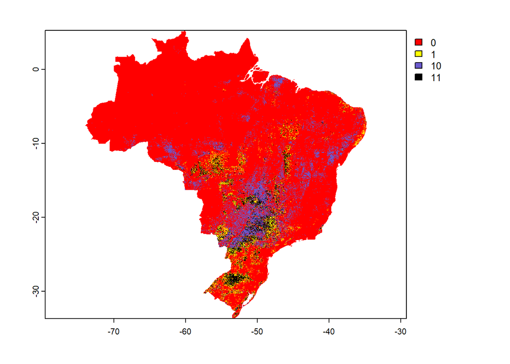

```r
# plot combined layer
plot(chen_mapbio_2015, col = c("red", "yellow", "slateblue", "black"))
```

#### Cropland + Mosaic ag

```r
# add chen and mapbiomas rasters
chen_mapbio_2015_mosaic <- mapbio_crop_2015_mosaic + chen_crop_2015_brazil

# return frequency of each value (0, 1, 10, 11) in new raster
counts2015 <- freq(chen_mapbio_2015_mosaic)
counts2015
```

```
##      layer value   count
## [1,]     1     0 7144324
## [2,]     1     1  467716
## [3,]     1    10  540014
## [4,]     1    11  336904
```

```r
# break up freq values ba
nocrop_2015 <- counts2015[1, 3]
crop_mapbio_only_2015 <- counts2015[2, 3]
crop_chen_only_2015 <- counts2015[3,3]
crop_both_2015 <- counts2015[4,3]

## break down into values for confusion matrix

# number of real positive cases (P), pixels for which mapbiomas observed cropland
p2 <- crop_mapbio_only_2015 + crop_both_2015
# number of real negative cases (N), pixels for which mapbiomas did not observe cropland
n2 <- nocrop_2015 + crop_chen_only_2015

# true positive
tp2 <- crop_both_2015
# false positive
fp2 <- crop_chen_only_2015
# true negative
tn2 <- nocrop_2015
# false negative
fn2 <- crop_mapbio_only_2015

## percentages/rates:
# sensitivity (true positive rate)
tpr2 <- tp2/p2
# specificity (true negative rate)
tnr2 <- tn2/n2
# false positive rate
fpr2 <- fp2/n2
# false negative rate
fnr2 <- fn2/p2

#accuracy
acc2 <- (tp2 + tn2)/(p2+n2)
#precision (positive predictive value)
ppv2 <- tp2/(tp2 + fp2)


cm_2015_mosaic <- matrix(c(tp2, fn2, fp2, tn2), ncol=2, byrow=TRUE)
colnames(cm_2015_mosaic) <- c("Predicted Positive", "Predicted Negative")
rownames(cm_2015_mosaic) <- c("Observed Positive", "Observed Negative")
cm_2015_mosaic
```

```
##                   Predicted Positive Predicted Negative
## Observed Positive             336904             467716
## Observed Negative             540014            7144324
```

```r
cm_2015_mosaic_perc <- matrix(c(tpr2, fnr2, fpr2, tnr2), ncol=2, byrow=TRUE)
colnames(cm_2015_mosaic_perc) <- c("Predicted Positive", "Predicted Negative")
rownames(cm_2015_mosaic_perc) <- c("Observed Positive", "Observed Negative")
cm_2015_mosaic_perc
```

```
##                   Predicted Positive Predicted Negative
## Observed Positive         0.41871194          0.5812881
## Observed Negative         0.07027463          0.9297254
```

```r
acc2
```

```
##     count
## 0.8812893
```

```r
ppv2
```

```
##    count
## 0.384191
```

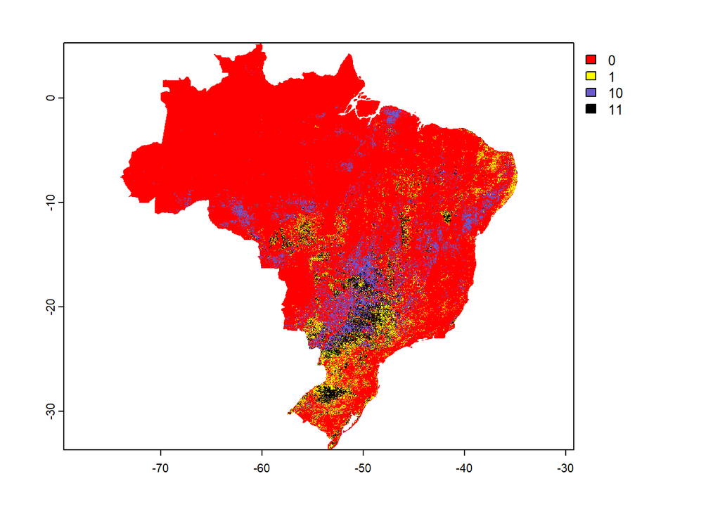

```r
# plot combined layer
plot(chen_mapbio_2015_mosaic, col = c("red", "yellow", "slateblue", "black"))
```

## On to greener pastures?

After exploring how MapBiomas’ mosaic agriculture and pasture land classification affect the confusion matrix between MapBiomas and Chen, we know want to explore how MapBiomas’ pasture classification affects the confusion matrix.

First, we want to run a quick check to see how much of the land classified as cropland my Chen is classified as pasture by MapBiomas. Quick visual inspection in QGIS reveals that the majority seems to be pasture, but we can quantify this below:

```r
# code to reclassify all 0 values in chen (non cropland) to NAs
chen_crop_ssp1_2020_brazil_na <- chen_crop_ssp1_2020_brazil
chen_crop_ssp1_2020_brazil_na[chen_crop_ssp1_2020_brazil_na == 0] <- NA

# then mask mapbio by chen to remove all values in mapbio that aren't Chen cropland for 2020
mapbio_2020_cropped_masked <- mapbio_2020_cropped %>%
  mask(chen_crop_ssp1_2020_brazil_na)

# reclassify mapbio to remove values for cropland in mapbiomas
df_nocrop <- c (39, 0,  #soybean
                20, 0,  #sugar cane
                40, 0,  #rice
                41, 0,  #other temp crops
                46, 0,  #coffee
                47, 0,  #citrus
                48, 0)  #other perennial crops

# reshape df into matrix with columns and rows
mapbio_m <- matrix(df_nocrop, ncol = 2, byrow = TRUE)

# use terra:classify() to reclassify raster values based on matrix
mapbio_2020_cropped_masked_reclass <- classify(mapbio_2020_cropped_masked, mapbio_m)

freq(mapbio_2020_cropped_masked_reclass)
```

```
##       layer value  count
##  [1,]     1     0 329822
##  [2,]     1     3  25180
##  [3,]     1     4  24518
##  [4,]     1     5      2
##  [5,]     1     9   8046
##  [6,]     1    11    952
##  [7,]     1    12  12616
##  [8,]     1    13    126
##  [9,]     1    15 478508
## [10,]     1    21  72579
## [11,]     1    23     34
## [12,]     1    24   3941
## [13,]     1    25    600
## [14,]     1    29     21
## [15,]     1    30     49
## [16,]     1    31      1
## [17,]     1    33    528
## [18,]     1    49      5
```

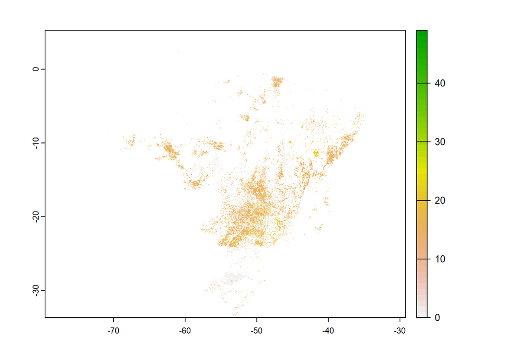

```r
plot(mapbio_2020_cropped_masked_reclass)
```

Yes, the majority of mis-matched pixels are classified as either “pasture” (15) or “mosaic agriculture and pasture” (21) by Mapbiomas

Now we want to re-run the confusion matrices to see how the results are affected by including pasture into the crop classification for MapBiomas

```r
# include ag mosaic in new reclassification
reclass_df_pasture <- c(3, 0,   #forest formation
                4, 0,   #savanna formation
                5, 0,   #mangrove
                49, 0,  #wooded restinga
                11, 0,  #wetlands
                12, 0,  #grassland
                32, 0,  #salt flat
                29, 0,  #rocky outcrop
                13, 0,  #other nonforest formations
                15, 1,  #pasture
                9, 0,   #forest plantation
                21, 0,  #mosaic ag and pasture
                23, 0,  #beach, dune, and sand spot
                24, 0,  #urban area
                30, 0,  #mining
                25, 0,  #other non vegetated areas
                33, 0,  # river, lake, ocean
                31, 0,  #aquaculture
                27, 0,  #non observed
                39, 1,  #soybean
                20, 1,  #sugar cane
                40, 1,  #rice
                41, 1,  #other temp crops
                46, 1,  #coffee
                47, 1,  #citrus
                48, 1)  #other perennial crops

reclass_m_pasture <- matrix(reclass_df_pasture, ncol = 2, byrow = TRUE)

mapbio_2020_reclass_pasture <- classify(mapbio_2020_cropped, reclass_m_pasture)

mapbio_crop_2020_pasture <- project(mapbio_2020_reclass_pasture, crs(chen_crop_ssp1_2020_brazil), method = "near")
```

### SSP1

```r
# add chen and mapbiomas rasters
chen_mapbio_ssp1_2020_pasture <- mapbio_crop_2020_pasture + chen_crop_ssp1_2020_brazil

# return frequency of each value (0, 1, 10, 11) in new raster
counts_1p <- freq(chen_mapbio_ssp1_2020_pasture)
counts_1p
```

```
##      layer value   count
## [1,]     1     0 5999316
## [2,]     1     1 1532114
## [3,]     1    10  149350
## [4,]     1    11  808178
```

```r
# break up freq values ba
nocrop_1p <- counts_1p[1, 3]
crop_mapbio_only_1p <- counts_1p[2, 3]
crop_chen_only_1p <- counts_1p[3,3]
crop_both_1p <- counts_1p[4,3]

## break down into values for confusion matrix

# number of real positive cases (P), pixels for which mapbiomas observed cropland
p_1p <- crop_mapbio_only_1p + crop_both_1p
# number of real negative cases (N), pixels for which mapbiomas did not observe cropland
n_1p <- nocrop_1p + crop_chen_only_1p

# true positive
tp_1p <- crop_both_1p
# false positive
fp_1p <- crop_chen_only_1p
# true negative
tn_1p <- nocrop_1p
# false negative
fn_1p <- crop_mapbio_only_1p

## percentages/rates:
# sensitivity (true positive rate)
tpr_1p <- tp_1p/p_1p
# specificity (true negative rate)
tnr_1p <- tn_1p/n_1p
# false positive rate
fpr_1p <- fp_1p/n_1p
# false negative rate
fnr_1p <- fn_1p/p_1p

#accuracy
acc_1p <- (tp_1p + tn_1p)/(p_1p + n_1p)
#precision (positive predictive value)
ppv_1p <- tp_1p/(tp_1p + fp_1p)


cm_ssp1_2020_p <- matrix(c(tp_1p, fn_1p, fp_1p, tn_1p), ncol=2, byrow=TRUE)
colnames(cm_ssp1_2020_p) <- c("Predicted Positive", "Predicted Negative")
rownames(cm_ssp1_2020_p) <- c("Observed Positive", "Observed Negative")


cm_ssp1_2020_perc_p <- matrix(c(tpr_1p, fnr_1p, fpr_1p, tnr_1p), ncol=2, byrow=TRUE)
colnames(cm_ssp1_2020_perc_p) <- c("Predicted Positive", "Predicted Negative")
rownames(cm_ssp1_2020_perc_p) <- c("Observed Positive", "Observed Negative")

cm_ssp1_2020_p
```

```
##                   Predicted Positive Predicted Negative
## Observed Positive             808178            1532114
## Observed Negative             149350            5999316
```

```r
cm_ssp1_2020_perc_p
```

```
##                   Predicted Positive Predicted Negative
## Observed Positive         0.34533212          0.6546679
## Observed Negative         0.02428982          0.9757102
```

```r
acc_1p
```

```
##     count
## 0.8019234
```

```r
ppv_1p
```

```
##     count
## 0.8440254
```

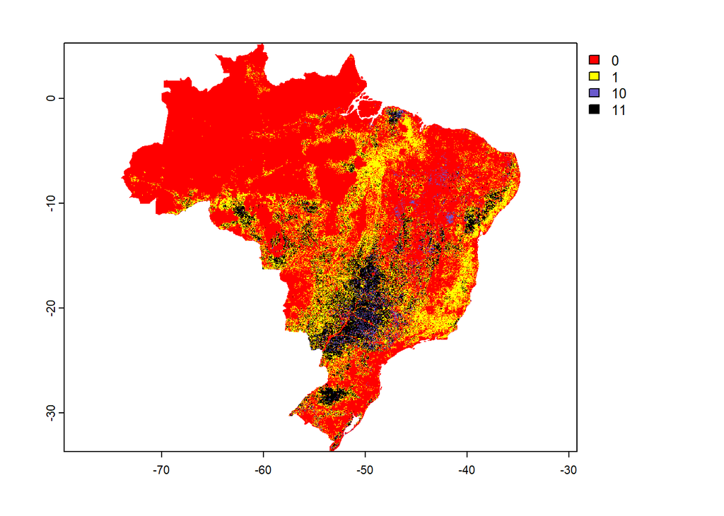

```r
# plot combined layer
plot(chen_mapbio_ssp1_2020_pasture, col = c("red", "yellow", "slateblue", "black"))
```

### SSP3

```r
# add chen and mapbiomas rasters
chen_mapbio_ssp3_2020_pasture <- mapbio_crop_2020_pasture + chen_crop_ssp3_2020_brazil

# return frequency of each value (0, 1, 10, 11) in new raster
counts_3p <- freq(chen_mapbio_ssp3_2020_pasture)
counts_3p
```

```
##      layer value   count
## [1,]     1     0 5988564
## [2,]     1     1 1493496
## [3,]     1    10  160102
## [4,]     1    11  846796
```

```r
# break up freq values ba
nocrop_3p <- counts_3p[1, 3]
crop_mapbio_only_3p <- counts_3p[2, 3]
crop_chen_only_3p <- counts_3p[3,3]
crop_both_3p <- counts_3p[4,3]

## break down into values for confusion matrix

# number of real positive cases (P), pixels for which mapbiomas observed cropland
p_3p <- crop_mapbio_only_3p + crop_both_3p
# number of real negative cases (N), pixels for which mapbiomas did not observe cropland
n_3p <- nocrop_3p + crop_chen_only_3p

# true positive
tp_3p <- crop_both_3p
# false positive
fp_3p <- crop_chen_only_3p
# true negative
tn_3p <- nocrop_3p
# false negative
fn_3p <- crop_mapbio_only_3p

## percentages/rates:
# sensitivity (true positive rate)
tpr_3p <- tp_3p/p_3p
# specificity (true negative rate)
tnr_3p <- tn_3p/n_3p
# false positive rate
fpr_3p <- fp_3p/n_3p
# false negative rate
fnr_3p <- fn_3p/p_3p

#accuracy
acc_3p <- (tp_3p + tn_3p)/(p_3p + n_3p)
#precision (positive predictive value)
ppv_3p <- tp_3p/(tp_3p + fp_3p)


cm_ssp3_2020_p <- matrix(c(tp_3p, fn_3p, fp_3p, tn_3p), ncol=2, byrow=TRUE)
colnames(cm_ssp3_2020_p) <- c("Predicted Positive", "Predicted Negative")
rownames(cm_ssp3_2020_p) <- c("Observed Positive", "Observed Negative")


cm_ssp3_2020_perc_p <- matrix(c(tpr_3p, fnr_3p, fpr_3p, tnr_3p), ncol=2, byrow=TRUE)
colnames(cm_ssp3_2020_perc_p) <- c("Predicted Positive", "Predicted Negative")
rownames(cm_ssp3_2020_perc_p) <- c("Observed Positive", "Observed Negative")

cm_ssp3_2020_p
```

```
##                   Predicted Positive Predicted Negative
## Observed Positive             846796            1493496
## Observed Negative             160102            5988564
```

```r
cm_ssp3_2020_perc_p
```

```
##                   Predicted Positive Predicted Negative
## Observed Positive         0.36183348          0.6381665
## Observed Negative         0.02603849          0.9739615
```

```r
acc_3p
```

```
##    count
## 0.805206
```

```r
ppv_3p
```

```
##     count
## 0.8409948
```

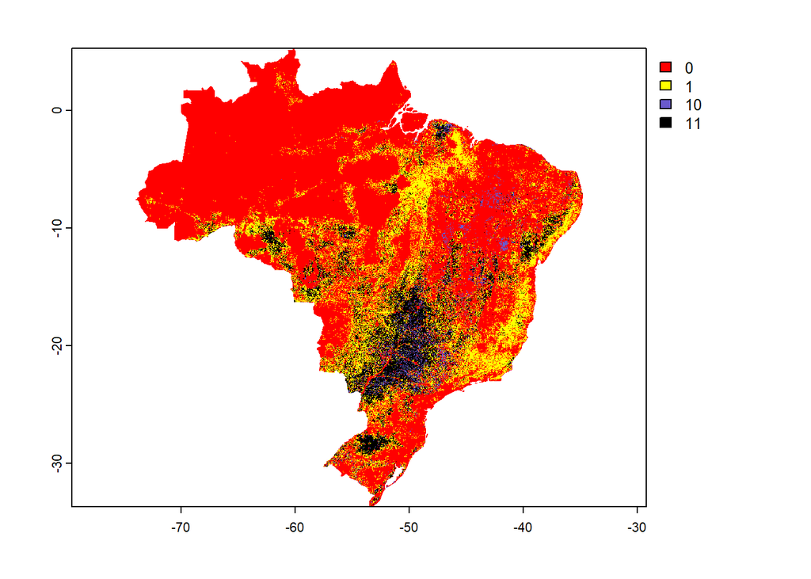

```r
# plot combined layer
plot(chen_mapbio_ssp3_2020_pasture, col = c("red", "yellow", "slateblue", "black"))
```

### SSP5

```r
# add chen and mapbiomas rasters
chen_mapbio_ssp5_2020_pasture <- mapbio_crop_2020_pasture + chen_crop_ssp5_2020_brazil

# return frequency of each value (0, 1, 10, 11) in new raster
counts_5p <- freq(chen_mapbio_ssp5_2020_pasture)
counts_5p
```

```
##      layer value   count
## [1,]     1     0 5886178
## [2,]     1     1 1282579
## [3,]     1    10  262488
## [4,]     1    11 1057713
```

```r
# break up freq values ba
nocrop_5p <- counts_5p[1, 3]
crop_mapbio_only_5p <- counts_5p[2, 3]
crop_chen_only_5p <- counts_5p[3,3]
crop_both_5p <- counts_5p[4,3]

## break down into values for confusion matrix

# number of real positive cases (P), pixels for which mapbiomas observed cropland
p_5p <- crop_mapbio_only_5p + crop_both_5p
# number of real negative cases (N), pixels for which mapbiomas did not observe cropland
n_5p <- nocrop_5p + crop_chen_only_5p

# true positive
tp_5p <- crop_both_5p
# false positive
fp_5p <- crop_chen_only_5p
# true negative
tn_5p <- nocrop_5p
# false negative
fn_5p <- crop_mapbio_only_5p

## percentages/rates:
# sensitivity (true positive rate)
tpr_5p <- tp_5p/p_5p
# specificity (true negative rate)
tnr_5p <- tn_5p/n_5p
# false positive rate
fpr_5p <- fp_5p/n_5p
# false negative rate
fnr_5p <- fn_5p/p_5p

#accuracy
acc_5p <- (tp_5p + tn_5p)/(p_5p + n_5p)
#precision (positive predictive value)
ppv_5p <- tp_5p/(tp_5p + fp_5p)


cm_ssp5_2020_p <- matrix(c(tp_5p, fn_5p, fp_5p, tn_5p), ncol=2, byrow=TRUE)
colnames(cm_ssp5_2020_p) <- c("Predicted Positive", "Predicted Negative")
rownames(cm_ssp5_2020_p) <- c("Observed Positive", "Observed Negative")


cm_ssp5_2020_perc_p <- matrix(c(tpr_5p, fnr_5p, fpr_5p, tnr_5p), ncol=2, byrow=TRUE)
colnames(cm_ssp5_2020_perc_p) <- c("Predicted Positive", "Predicted Negative")
rownames(cm_ssp5_2020_perc_p) <- c("Observed Positive", "Observed Negative")

cm_ssp5_2020_p
```

```
##                   Predicted Positive Predicted Negative
## Observed Positive            1057713            1282579
## Observed Negative             262488            5886178
```

```r
cm_ssp5_2020_perc_p
```

```
##                   Predicted Positive Predicted Negative
## Observed Positive         0.45195770          0.5480423
## Observed Negative         0.04269024          0.9573098
```

```r
acc_5p
```

```
##    count
## 0.817991
```

```r
ppv_5p
```

```
##     count
## 0.8011757
```

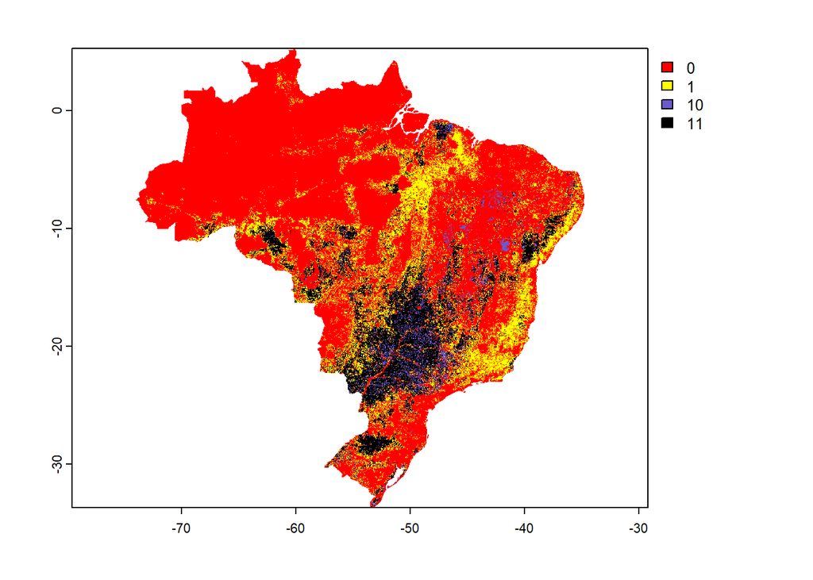

```r
# plot combined layer
plot(chen_mapbio_ssp5_2020_pasture, col = c("red", "yellow", "slateblue", "black"))
```